# LAboratorio 2

```r
view(flights)
```

[output not shown]

1. Inner-Join

1.1 Conecte fligts con planes

| year.x | month | day | dep_time | sched_dep_time | dep_delay | arr_time | sched_arr_time | arr_delay | carrier | flight | tailnum | origin | dest | air_time | distance | hour | minute | time_hour | year.y | type | manufacturer | model | engines | seats | speed | engine |
| --- | --- | --- | --- | --- | --- | --- | --- | --- | --- | --- | --- | --- | --- | --- | --- | --- | --- | --- | --- | --- | --- | --- | --- | --- | --- | --- |
| 2013 | 1 | 1 | 517 | 515 | 2 | 830 | 819 | 11 | UA | 1545 | N14228 | EWR | IAH | 227 | 1400 | 5 | 15 | 2013-01-01 05:00:00 | 1999 | Fixed wing multi engine | BOEING | 737-824 | 2 | 149 | NA | Turbo-fan |
| 2013 | 1 | 1 | 533 | 529 | 4 | 850 | 830 | 20 | UA | 1714 | N24211 | LGA | IAH | 227 | 1416 | 5 | 29 | 2013-01-01 05:00:00 | 1998 | Fixed wing multi engine | BOEING | 737-824 | 2 | 149 | NA | Turbo-fan |
| 2013 | 1 | 1 | 542 | 540 | 2 | 923 | 850 | 33 | AA | 1141 | N619AA | JFK | MIA | 160 | 1089 | 5 | 40 | 2013-01-01 05:00:00 | 1990 | Fixed wing multi engine | BOEING | 757-223 | 2 | 178 | NA | Turbo-fan |
| 2013 | 1 | 1 | 544 | 545 | -1 | 1004 | 1022 | -18 | B6 | 725 | N804JB | JFK | BQN | 183 | 1576 | 5 | 45 | 2013-01-01 05:00:00 | 2012 | Fixed wing multi engine | AIRBUS | A320-232 | 2 | 200 | NA | Turbo-fan |
| 2013 | 1 | 1 | 554 | 600 | -6 | 812 | 837 | -25 | DL | 461 | N668DN | LGA | ATL | 116 | 762 | 6 | 0 | 2013-01-01 06:00:00 | 1991 | Fixed wing multi engine | BOEING | 757-232 | 2 | 178 | NA | Turbo-fan |
| 2013 | 1 | 1 | 554 | 558 | -4 | 740 | 728 | 12 | UA | 1696 | N39463 | EWR | ORD | 150 | 719 | 5 | 58 | 2013-01-01 05:00:00 | 2012 | Fixed wing multi engine | BOEING | 737-924ER | 2 | 191 | NA | Turbo-fan |
| 2013 | 1 | 1 | 555 | 600 | -5 | 913 | 854 | 19 | B6 | 507 | N516JB | EWR | FLL | 158 | 1065 | 6 | 0 | 2013-01-01 06:00:00 | 2000 | Fixed wing multi engine | AIRBUS INDUSTRIE | A320-232 | 2 | 200 | NA | Turbo-fan |
| 2013 | 1 | 1 | 557 | 600 | -3 | 709 | 723 | -14 | EV | 5708 | N829AS | LGA | IAD | 53 | 229 | 6 | 0 | 2013-01-01 06:00:00 | 1998 | Fixed wing multi engine | CANADAIR | CL-600-2B19 | 2 | 55 | NA | Turbo-fan |
| 2013 | 1 | 1 | 557 | 600 | -3 | 838 | 846 | -8 | B6 | 79 | N593JB | JFK | MCO | 140 | 944 | 6 | 0 | 2013-01-01 06:00:00 | 2004 | Fixed wing multi engine | AIRBUS | A320-232 | 2 | 200 | NA | Turbo-fan |
| 2013 | 1 | 1 | 558 | 600 | -2 | 849 | 851 | -2 | B6 | 49 | N793JB | JFK | PBI | 149 | 1028 | 6 | 0 | 2013-01-01 06:00:00 | 2011 | Fixed wing multi engine | AIRBUS | A320-232 | 2 | 200 | NA | Turbo-fan |

[output cut: 990 more lines]

1.2 Conecte flights con airlines

| year | month | day | dep_time | sched_dep_time | dep_delay | arr_time | sched_arr_time | arr_delay | carrier | flight | tailnum | origin | dest | air_time | distance | hour | minute | time_hour | name |
| --- | --- | --- | --- | --- | --- | --- | --- | --- | --- | --- | --- | --- | --- | --- | --- | --- | --- | --- | --- |
| 2013 | 1 | 1 | 517 | 515 | 2 | 830 | 819 | 11 | UA | 1545 | N14228 | EWR | IAH | 227 | 1400 | 5 | 15 | 2013-01-01 05:00:00 | United Air Lines Inc. |
| 2013 | 1 | 1 | 533 | 529 | 4 | 850 | 830 | 20 | UA | 1714 | N24211 | LGA | IAH | 227 | 1416 | 5 | 29 | 2013-01-01 05:00:00 | United Air Lines Inc. |
| 2013 | 1 | 1 | 542 | 540 | 2 | 923 | 850 | 33 | AA | 1141 | N619AA | JFK | MIA | 160 | 1089 | 5 | 40 | 2013-01-01 05:00:00 | American Airlines Inc. |
| 2013 | 1 | 1 | 544 | 545 | -1 | 1004 | 1022 | -18 | B6 | 725 | N804JB | JFK | BQN | 183 | 1576 | 5 | 45 | 2013-01-01 05:00:00 | JetBlue Airways |
| 2013 | 1 | 1 | 554 | 600 | -6 | 812 | 837 | -25 | DL | 461 | N668DN | LGA | ATL | 116 | 762 | 6 | 0 | 2013-01-01 06:00:00 | Delta Air Lines Inc. |
| 2013 | 1 | 1 | 554 | 558 | -4 | 740 | 728 | 12 | UA | 1696 | N39463 | EWR | ORD | 150 | 719 | 5 | 58 | 2013-01-01 05:00:00 | United Air Lines Inc. |
| 2013 | 1 | 1 | 555 | 600 | -5 | 913 | 854 | 19 | B6 | 507 | N516JB | EWR | FLL | 158 | 1065 | 6 | 0 | 2013-01-01 06:00:00 | JetBlue Airways |
| 2013 | 1 | 1 | 557 | 600 | -3 | 709 | 723 | -14 | EV | 5708 | N829AS | LGA | IAD | 53 | 229 | 6 | 0 | 2013-01-01 06:00:00 | ExpressJet Airlines Inc. |
| 2013 | 1 | 1 | 557 | 600 | -3 | 838 | 846 | -8 | B6 | 79 | N593JB | JFK | MCO | 140 | 944 | 6 | 0 | 2013-01-01 06:00:00 | JetBlue Airways |
| 2013 | 1 | 1 | 558 | 600 | -2 | 753 | 745 | 8 | AA | 301 | N3ALAA | LGA | ORD | 138 | 733 | 6 | 0 | 2013-01-01 06:00:00 | American Airlines Inc. |

[output cut: 990 more lines]

1.3 Conecte flights con airports

[output not shown]

[output cut: 990 more lines]

1.4 Conecte flights con weather (según esquema de arriba, hay 5 variables que relacionan a ambas tablas)

| year | month | day | dep_time | sched_dep_time | dep_delay | arr_time | sched_arr_time | arr_delay | carrier | flight | tailnum | origin | dest | air_time | distance | hour | minute | time_hour.x | temp | dewp | humid | wind_dir | wind_speed | wind_gust | precip | pressure | visib | time_hour.y |
| --- | --- | --- | --- | --- | --- | --- | --- | --- | --- | --- | --- | --- | --- | --- | --- | --- | --- | --- | --- | --- | --- | --- | --- | --- | --- | --- | --- | --- |
| 2013 | 1 | 1 | 517 | 515 | 2 | 830 | 819 | 11 | UA | 1545 | N14228 | EWR | IAH | 227 | 1400 | 5 | 15 | 2013-01-01 05:00:00 | 39.02 | 28.04 | 64.43 | 260 | 12.65858 | NA | 0 | 1011.9 | 10 | 2013-01-01 05:00:00 |
| 2013 | 1 | 1 | 533 | 529 | 4 | 850 | 830 | 20 | UA | 1714 | N24211 | LGA | IAH | 227 | 1416 | 5 | 29 | 2013-01-01 05:00:00 | 39.92 | 24.98 | 54.81 | 250 | 14.96014 | 21.86482 | 0 | 1011.4 | 10 | 2013-01-01 05:00:00 |
| 2013 | 1 | 1 | 542 | 540 | 2 | 923 | 850 | 33 | AA | 1141 | N619AA | JFK | MIA | 160 | 1089 | 5 | 40 | 2013-01-01 05:00:00 | 39.02 | 26.96 | 61.63 | 260 | 14.96014 | NA | 0 | 1012.1 | 10 | 2013-01-01 05:00:00 |
| 2013 | 1 | 1 | 544 | 545 | -1 | 1004 | 1022 | -18 | B6 | 725 | N804JB | JFK | BQN | 183 | 1576 | 5 | 45 | 2013-01-01 05:00:00 | 39.02 | 26.96 | 61.63 | 260 | 14.96014 | NA | 0 | 1012.1 | 10 | 2013-01-01 05:00:00 |
| 2013 | 1 | 1 | 554 | 600 | -6 | 812 | 837 | -25 | DL | 461 | N668DN | LGA | ATL | 116 | 762 | 6 | 0 | 2013-01-01 06:00:00 | 39.92 | 24.98 | 54.81 | 260 | 16.11092 | 23.01560 | 0 | 1011.7 | 10 | 2013-01-01 06:00:00 |
| 2013 | 1 | 1 | 554 | 558 | -4 | 740 | 728 | 12 | UA | 1696 | N39463 | EWR | ORD | 150 | 719 | 5 | 58 | 2013-01-01 05:00:00 | 39.02 | 28.04 | 64.43 | 260 | 12.65858 | NA | 0 | 1011.9 | 10 | 2013-01-01 05:00:00 |
| 2013 | 1 | 1 | 555 | 600 | -5 | 913 | 854 | 19 | B6 | 507 | N516JB | EWR | FLL | 158 | 1065 | 6 | 0 | 2013-01-01 06:00:00 | 37.94 | 28.04 | 67.21 | 240 | 11.50780 | NA | 0 | 1012.4 | 10 | 2013-01-01 06:00:00 |
| 2013 | 1 | 1 | 557 | 600 | -3 | 709 | 723 | -14 | EV | 5708 | N829AS | LGA | IAD | 53 | 229 | 6 | 0 | 2013-01-01 06:00:00 | 39.92 | 24.98 | 54.81 | 260 | 16.11092 | 23.01560 | 0 | 1011.7 | 10 | 2013-01-01 06:00:00 |
| 2013 | 1 | 1 | 557 | 600 | -3 | 838 | 846 | -8 | B6 | 79 | N593JB | JFK | MCO | 140 | 944 | 6 | 0 | 2013-01-01 06:00:00 | 37.94 | 26.96 | 64.29 | 260 | 13.80936 | NA | 0 | 1012.6 | 10 | 2013-01-01 06:00:00 |
| 2013 | 1 | 1 | 558 | 600 | -2 | 753 | 745 | 8 | AA | 301 | N3ALAA | LGA | ORD | 138 | 733 | 6 | 0 | 2013-01-01 06:00:00 | 39.92 | 24.98 | 54.81 | 260 | 16.11092 | 23.01560 | 0 | 1011.7 | 10 | 2013-01-01 06:00:00 |

[output cut: 990 more lines]

2. Data Manipulation

2.1 Utilice el verbo count en flights y envíe como parámetro las variables year, month, day. Luego filtre n para que sea mayor a 1000. Por último ordene n con el verbo arrange y devuelva el resultado

| year | month | day | n |
| --- | --- | --- | --- |
| 2013 | 11 | 27 | 1014 |
| 2013 | 7 | 11 | 1006 |
| 2013 | 7 | 8 | 1004 |
| 2013 | 7 | 10 | 1004 |
| 2013 | 12 | 2 | 1004 |
| 2013 | 7 | 18 | 1003 |
| 2013 | 7 | 25 | 1003 |
| 2013 | 7 | 12 | 1002 |
| 2013 | 7 | 9 | 1001 |
| 2013 | 7 | 17 | 1001 |

[output cut: 4 more lines]

2.2. Utilice el concepto de selección por rango (aplicando el operador “:”) para obtener las variables year hacia day. También agregue a esta selección hour, origin, dest, tailnum, carrier, arr_delay, dep_delay, por último almacene el resultado en la variable flights_selected.

| hour | origin | dest | tailnum | carrier | arr_delay | dep_delay | year | month | day |
| --- | --- | --- | --- | --- | --- | --- | --- | --- | --- |
| 5 | EWR | IAH | N14228 | UA | 11 | 2 | 2013 | 1 | 1 |
| 5 | LGA | IAH | N24211 | UA | 20 | 4 | 2013 | 1 | 1 |
| 5 | JFK | MIA | N619AA | AA | 33 | 2 | 2013 | 1 | 1 |
| 5 | JFK | BQN | N804JB | B6 | -18 | -1 | 2013 | 1 | 1 |
| 6 | LGA | ATL | N668DN | DL | -25 | -6 | 2013 | 1 | 1 |
| 5 | EWR | ORD | N39463 | UA | 12 | -4 | 2013 | 1 | 1 |
| 6 | EWR | FLL | N516JB | B6 | 19 | -5 | 2013 | 1 | 1 |
| 6 | LGA | IAD | N829AS | EV | -14 | -3 | 2013 | 1 | 1 |
| 6 | JFK | MCO | N593JB | B6 | -8 | -3 | 2013 | 1 | 1 |
| 6 | LGA | ORD | N3ALAA | AA | 8 | -2 | 2013 | 1 | 1 |

[output cut: 990 more lines]

2.3. Utilice left_join para combinar airlines y flights_selected. Al obtener el resultado, utilice el verbo select para eliminar las columnas origin y dest (utilice el operador “-” para descartar estas columnas únicamente). Por último agregue una nueva columna con el verbo mutate, asigne el nombre tot_delay y opere la suma de arr_delay y dep_delay.

| carrier | name | hour | tailnum | arr_delay | dep_delay | year | month | day | tot_delay |
| --- | --- | --- | --- | --- | --- | --- | --- | --- | --- |
| 9E | Endeavor Air Inc. | 8 | N915XJ | 11 | 0 | 2013 | 1 | 1 | 11 |
| 9E | Endeavor Air Inc. | 15 | N8444F | -2 | -9 | 2013 | 1 | 1 | -11 |
| 9E | Endeavor Air Inc. | 14 | N920XJ | -2 | -3 | 2013 | 1 | 1 | -5 |
| 9E | Endeavor Air Inc. | 15 | N8409N | -1 | -6 | 2013 | 1 | 1 | -7 |
| 9E | Endeavor Air Inc. | 15 | N8631E | -5 | -8 | 2013 | 1 | 1 | -13 |
| 9E | Endeavor Air Inc. | 15 | N913XJ | -5 | 0 | 2013 | 1 | 1 | -5 |
| 9E | Endeavor Air Inc. | 15 | N904XJ | 5 | 6 | 2013 | 1 | 1 | 11 |
| 9E | Endeavor Air Inc. | 15 | N934XJ | 13 | 0 | 2013 | 1 | 1 | 13 |
| 9E | Endeavor Air Inc. | 16 | N910XJ | -8 | -8 | 2013 | 1 | 1 | -16 |
| 9E | Endeavor Air Inc. | 16 | N931XJ | -33 | -6 | 2013 | 1 | 1 | -39 |

[output cut: 990 more lines]

2.4. Utilice inner_join para combinar flights y weather, luego agrupe por la variable precip. Utilice summarize para encontrar el promedio de la variable dep_delay (aplicando la función mean), asigne al promedio el nombre delay. Al utilizar la función mean agregue el parámetro na.rm y asígnele TRUE por defecto. A continuación un ejemplo: mean(variable, na.rm = TRUE) Esta expresión simplemente indica a R que si encuentra valores perdidos en la variable los elimine. Luego agregue la función replace_na y aplíquelo a la variable delay sustituyendo NA por cero. Por último almacene el resultado en la variable precip_delay.

| precip | delay |
| --- | --- |
| 0.00 | 11.374509 |
| 0.01 | 29.802886 |
| 0.02 | 24.081196 |
| 0.03 | 28.739329 |
| 0.04 | 28.600265 |
| 0.05 | 29.379638 |
| 0.06 | 31.391616 |
| 0.07 | 27.703190 |
| 0.08 | 37.326172 |
| 0.09 | 40.211230 |

[output cut: 45 more lines]

2.5. Utilice la variable precip_delay para crear un gráfico de puntos tomando de eje x la variable precip y para y la variable delay.

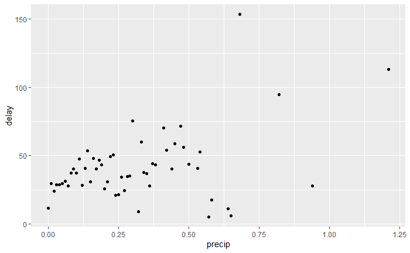

2.6. Utilice fligths y aplique filter tomando en cuenta la siguiente condición: Que year sea igual a 2013, que month sea igual a 5 y que day sea igual a 10. Luego agrupe por la variable dest. Después utilice summarize para obtener el promedio de la variable arr_delay, establezca el parámetro na.rm en TRUE y asigne al promedio el nombre de delay. Conecte el resultado anterior por medio de inner_join a la tabla airports y asignelo a la variable flights_airports.

| dest | delay | name | lat | lon | alt | tz | dst | tzone |
| --- | --- | --- | --- | --- | --- | --- | --- | --- |
| ABQ | 105.0000000 | Albuquerque International Sunport | 35.04022 | -106.60919 | 5355 | -7 | A | America/Denver |
| ALB | 26.5000000 | Albany Intl | 42.74827 | -73.80169 | 285 | -5 | A | America/New_York |
| ATL | 5.6800000 | Hartsfield Jackson Atlanta Intl | 33.63672 | -84.42807 | 1026 | -5 | A | America/New_York |
| AUS | 31.1666667 | Austin Bergstrom Intl | 30.19453 | -97.66989 | 542 | -6 | A | America/Chicago |
| AVL | -8.0000000 | Asheville Regional Airport | 35.43619 | -82.54181 | 2165 | -5 | A | America/New_York |
| BDL | -18.0000000 | Bradley Intl | 41.93889 | -72.68322 | 173 | -5 | A | America/New_York |
| BGR | -14.0000000 | Bangor Intl | 44.80744 | -68.82814 | 192 | -5 | A | America/New_York |
| BHM | 98.0000000 | Birmingham Intl | 33.56294 | -86.75355 | 644 | -6 | A | America/Chicago |
| BNA | 28.8421053 | Nashville Intl | 36.12447 | -86.67819 | 599 | -6 | A | America/Chicago |
| BOS | -0.3541667 | General Edward Lawrence Logan Intl | 42.36435 | -71.00518 | 19 | -5 | A | America/New_York |

[output cut: 73 more lines]

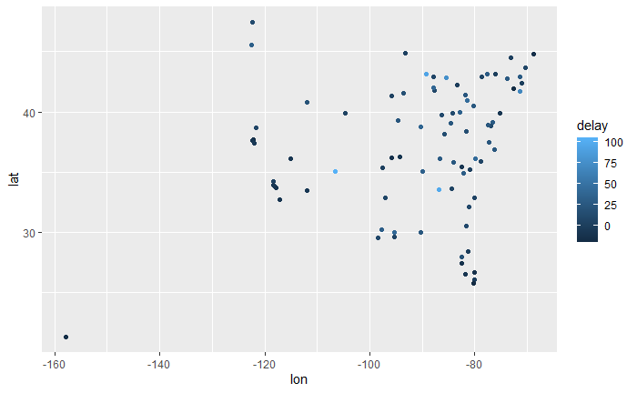

2.8. Utilice inner_join para combinar flights y planes. Agregue los sufijos _flights y _planes respectivamente. Por último utilice la función transmute para seleccionar las variables tailnum y manufacturer, pero además agregue la variable pi que almacene la suma de dep_delay y arr_delay, yluego divida por air_time. Ejemplo: (dep_delay + arr_delay) / air_time

| tailnum | manufacturer | pi |
| --- | --- | --- |
| N14228 | BOEING | 0.057268722 |
| N24211 | BOEING | 0.105726872 |
| N619AA | BOEING | 0.218750000 |
| N804JB | AIRBUS | -0.103825137 |
| N668DN | BOEING | -0.267241379 |
| N39463 | BOEING | 0.053333333 |
| N516JB | AIRBUS INDUSTRIE | 0.088607595 |
| N829AS | CANADAIR | -0.320754717 |
| N593JB | AIRBUS | -0.078571429 |
| N793JB | AIRBUS | -0.026845638 |

[output cut: 990 more lines]